# survey for cool white dwarfs and the age of the Galactic disc | Monthly Notices of the Royal Astronomical Society | Oxford Academic

## 3 Survey Limits and Sample Selection

The ‘catalogue’ resulting from the implementation of the procedure described in the previous section consists of astrometric and photometric measures for over 200 000 objects. Criteria for inclusion in this preliminary sample are merely detection in both *B*<sub>J</sub> and R passbands [since these are required for construction of the reduced proper motion diagram (RPMD)] and a measure of proper motion in both these passbands. It is from these objects that an uncontaminated proper motion sample is to be drawn, and we require well defined universal survey limits so that space densities can be calculated from the final survey sample.

Number count plots from this survey data increase linearly with increasing magnitude, as shown for the R data in Fig. 3, before dropping precipitously. This cut-off is attributed to the survey detection limit, and the position of the turnover is used to determine photometric survey limits. The limits used are 21.2 in R and 22.5 in B.

Figure 3.

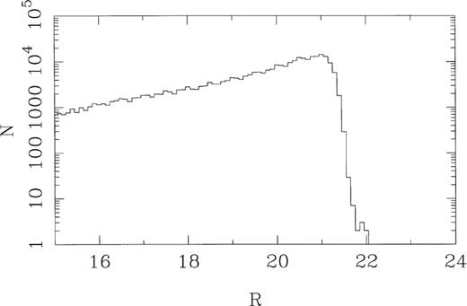

[Open in new tab](https://academic.oup.com/view-large/figure/17640906/306-3-736-fig003.jpeg)Download slide

Number counts as a function of apparent *R* magnitude.

The proper motion distribution for all objects in our survey area detected on at least 15 stacks in both *B* and *R* is shown in Fig. 4. Low proper motions are generally an artefact of measuring machine error; thus the distribution indicates a typical error in measured proper motions of ∼10 mas yr<sup>−1</sup>. Our criteria for choosing a survey proper motion limit are elimination of contaminant spurious proper motions from the sample and, with this in mind, maximizing the size of the final proper motion sample extracted. The deterioration of positional accuracy with magnitude means that fainter objects also have more uncertain proper motion determinations. The peak of the proper motion distribution therefore moves to higher proper motions with object samples drawn from progressively fainter magnitude bins. For this reason, we consider the survey proper motion limit as a function of magnitude.

Figure 4.

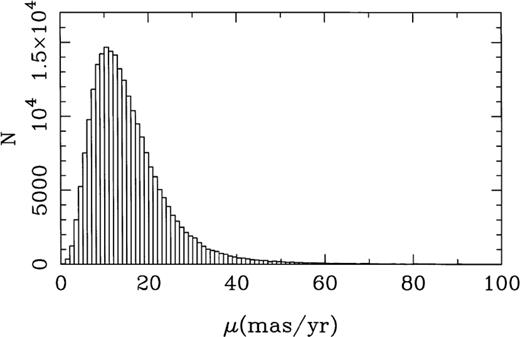

[Open in new tab](https://academic.oup.com/view-large/figure/17640908/306-3-736-fig004.jpeg)Download slide

Proper motion frequency distribution.

Three independent methods of determining an appropriate proper motion limit have been investigated for this dataset: all of which are described here.

- (1)

  analysis of proper motion error distribution;
- (2)

  cumulative proper motion number counts, and
- (3)

  RPMD inspection,

The characteristics of the ‘noise’ in the proper motion distribution can be analysed by assuming all objects are ‘zero proper motion objects’ and the calculated proper motions arise purely from random measurement error. The ‘true’ values of μ<sub>*x*</sub> and μ<sub>*y*</sub> measured by linear regression are therefore zero, and the random measurement errors give rise to a normal error distribution in μ<sub>*x*</sub> and μ<sub>*y*</sub> about zero with common σ. We are, of course, interested in the total proper motion, which follows a Rayleigh distribution of the form

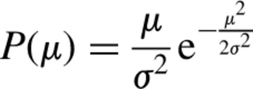

(1)

This survey utilizes two independent measures of proper motion in the same field, one from the stacks of B plates and the other from the R stacks. A useful means of reducing the final proper motion survey limit will be to compare these two measures and reject inconsistent motions. Comparison of independent measures of proper motion needs to be incorporated into this analysis if it is to be useful in predicting sample contamination later. The measured *B* and *R* motions and their associated error distributions are therefore characterized by

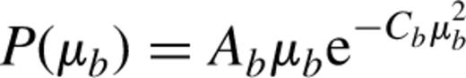

(2)

and

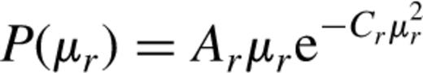

(3)

respectively. The algorithm used to select sample objects on the basis of proper motions will use three sequential cuts to eliminate spurious motions. First, the averaged proper motion must exceed the proper motion limit μ<sub>lim</sub>, i.e.,

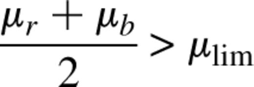

(4)

Secondly, the difference in proper motion must not exceed a second survey parameter (Δμ):

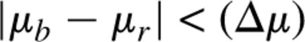

(5)

and, finally, the difference in position angle must not exceed a third survey parameter (Δφ):

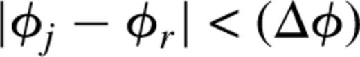

(6)

An object must satisfy all three of these criteria to be included in the sample. The desired outcome of this analysis is the ability to predict the expected contamination from spurious motions for a survey with parameters μ<sub>lim</sub>, (Δμ) and (Δφ), given the ‘zero proper motion object’ error distribution described by equations (2) and (3). In order to do this, we consider the combined probability distribution *P*(μ<sub>*b*</sub>)*P*(μ<sub>*r*</sub>) on the μ<sub>*b*</sub>−μ<sub>*r*</sub> plane.

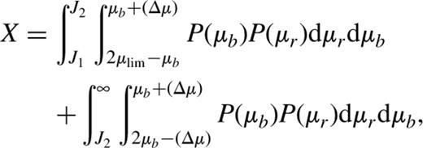

(7)

where

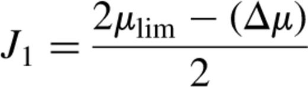

(8)

and

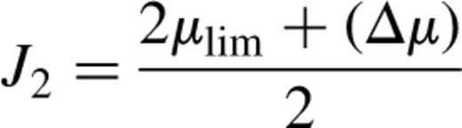

(9)

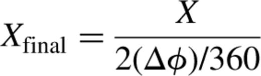

(10)